# Wei’s ANES Report 2022 - ANES Abortion Opinion Analysis

### Abstract

The 2020 ANES (American National Election Studies) time series dataset contains data from pre- and post-election surveys. This data compiles demographic information as well as political opinions from various respondents, including opinions on abortion, which is what my research focuses on. The supposed main goal behind the anti-abortion movement is preservation of life, as anti-abortionists are considered “pro-life.” Logically speaking, pro-lifers should also be against the death penalty if their ideal truly is to preserve life, right? I investigated this question by creating numerous visualisations and found that most pro-lifers are in favour of the death penalty, which raised the question: what factors *really* contribute to abortion opinions? Using many gbm models, I found that one’s political ideology (liberal or conservative) has the most effect on one’s opinion on abortion. Age and religion were the next variables with the highest relative influence, but both were not nearly as impactful on abortion opinions as political ideology. These results are important for understanding different views and the reasoning behind them, as well as increasing social awareness on this relevant issue—especially after the overturning of Roe v Wade.

### Background

ANES stands for American National Election Studies, the data is gathered from pre- and post-election surveys taken by Americans via the internet, video call, and phone call. Information gathered from these surveys include:

- political opinions
- income
- vote intention
- state of registration
- demographic information

The dataset contains data from 8,280 pre-election surveys and 7,449 post-election surveys conducted in 2020, my research makes use of only the pre-election survey data.

### Research Question

Are people who are against abortion also against the death penalty due to the logic of “pro-life” ideals? Or is the disapproval of abortion more closely tied to another factor like religion or culture rather than the conservation of life?

### Hypotheses

**Null**: a person’s opinion on abortion and the death penalty are unrelated and have no correlation  
**Alternate**: a person’s opinion on abortion and the death penalty are related and not independent of each other since both views are pro-life

### Plots and Figures

###### Figure 1

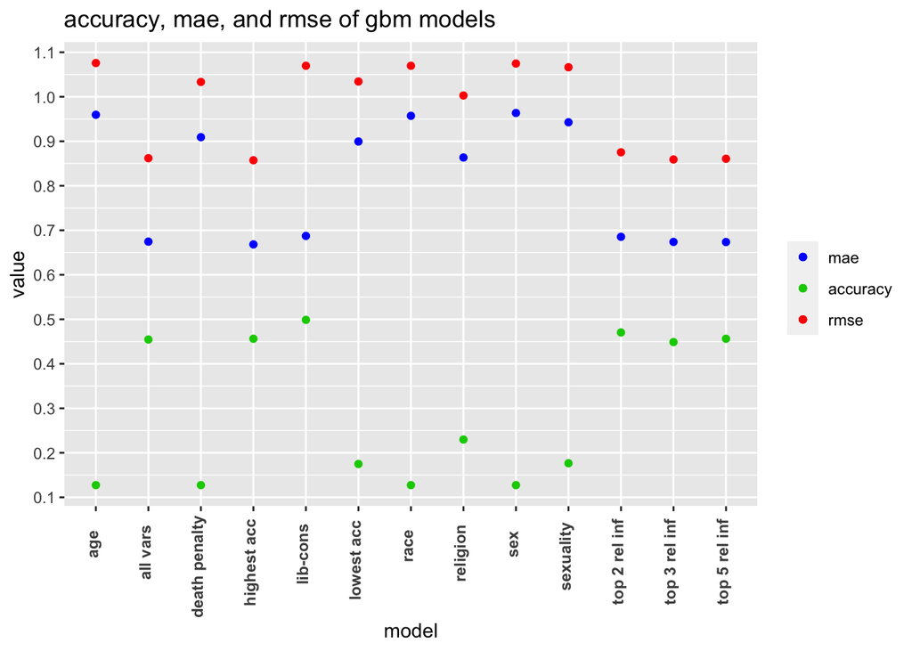

| Variable | Relative Influence |  |
| --- | --- | --- |
| libCons | 73.368505 |  |
| religion | 11.861502 |  |
| age | 9.524579 |  |
| race | 2.280825 |  |
| deathPenalty | 1.681733 |  |
| sexuality | 0.990996 |  |
| sex | 0.291860 |  |

###### Figure 2

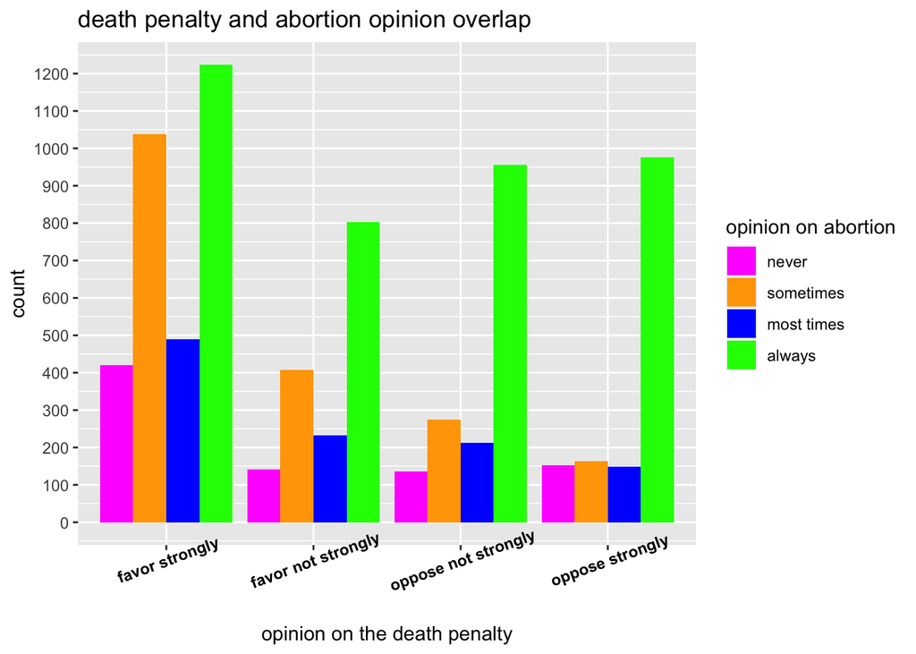

###### Figure 3

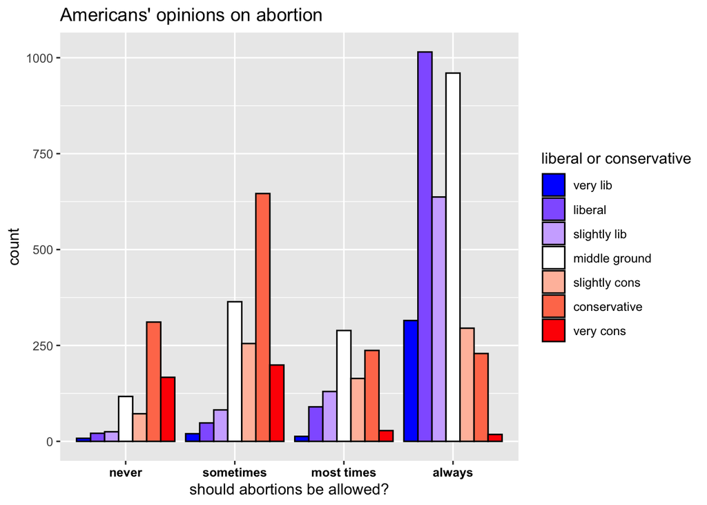

###### Figure 4

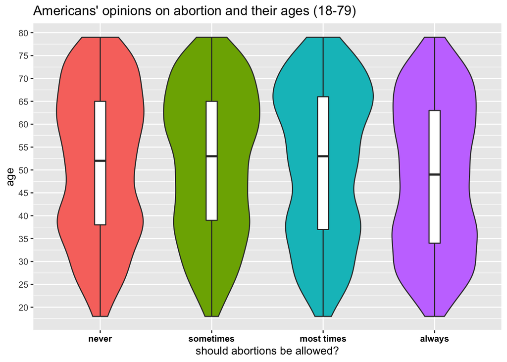

###### Figure 5

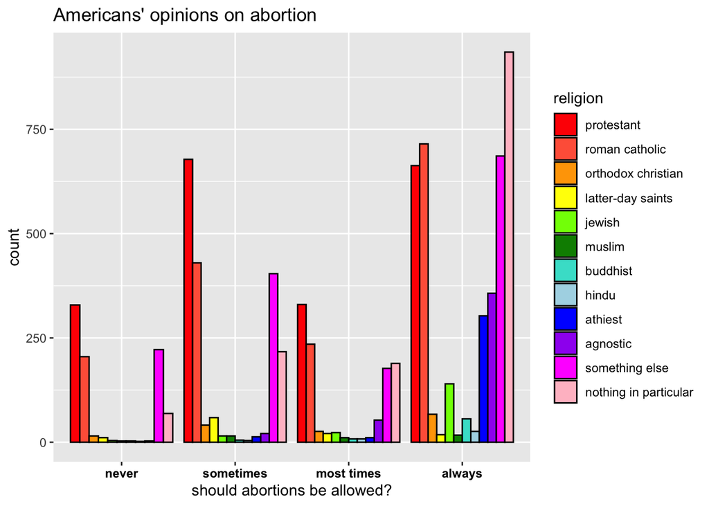

###### Figure 6-9

the following figures show grouped religions to better see the distribution

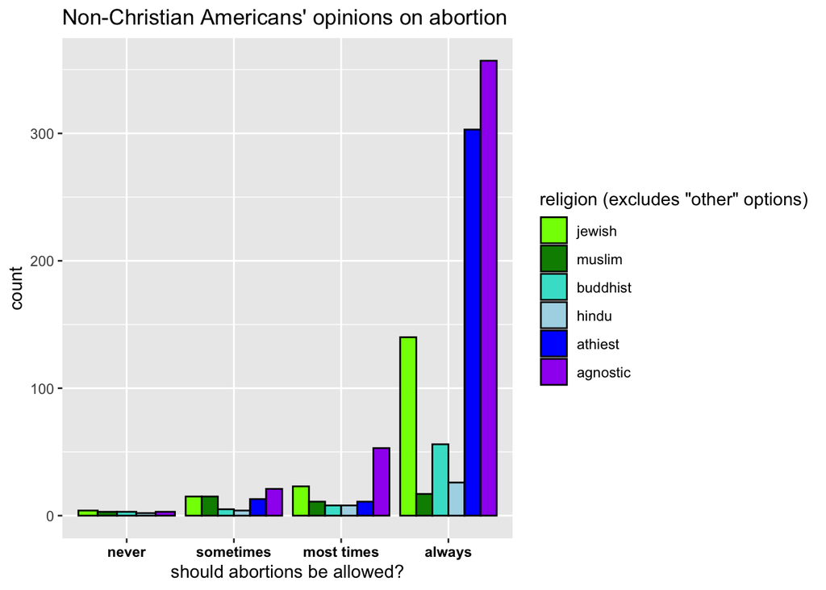

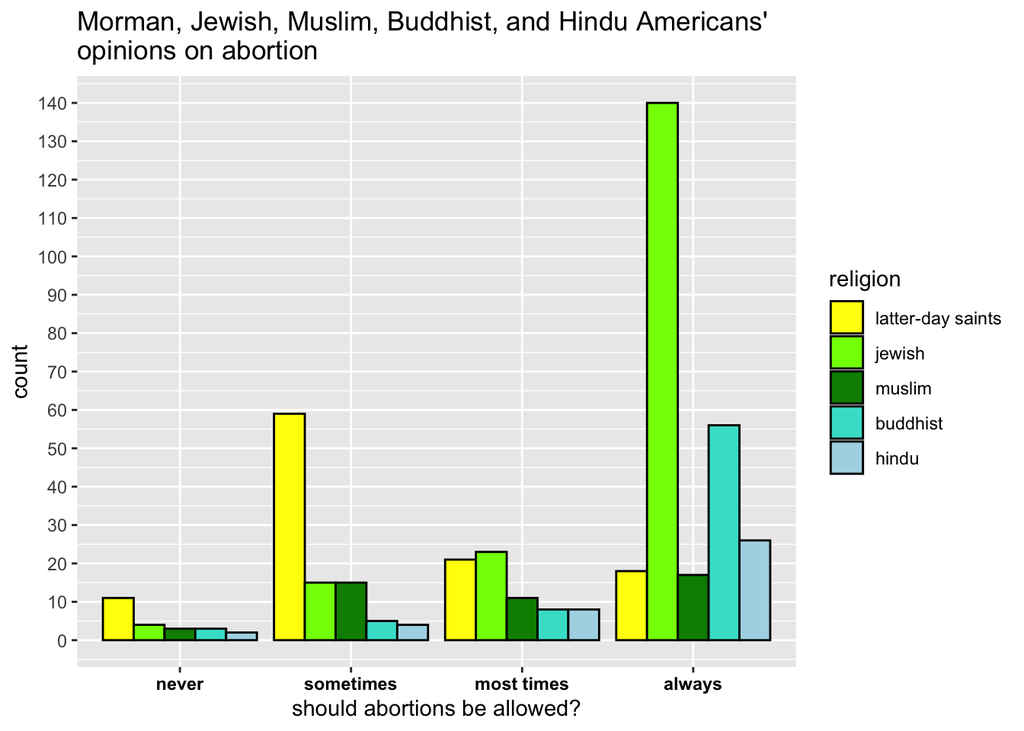

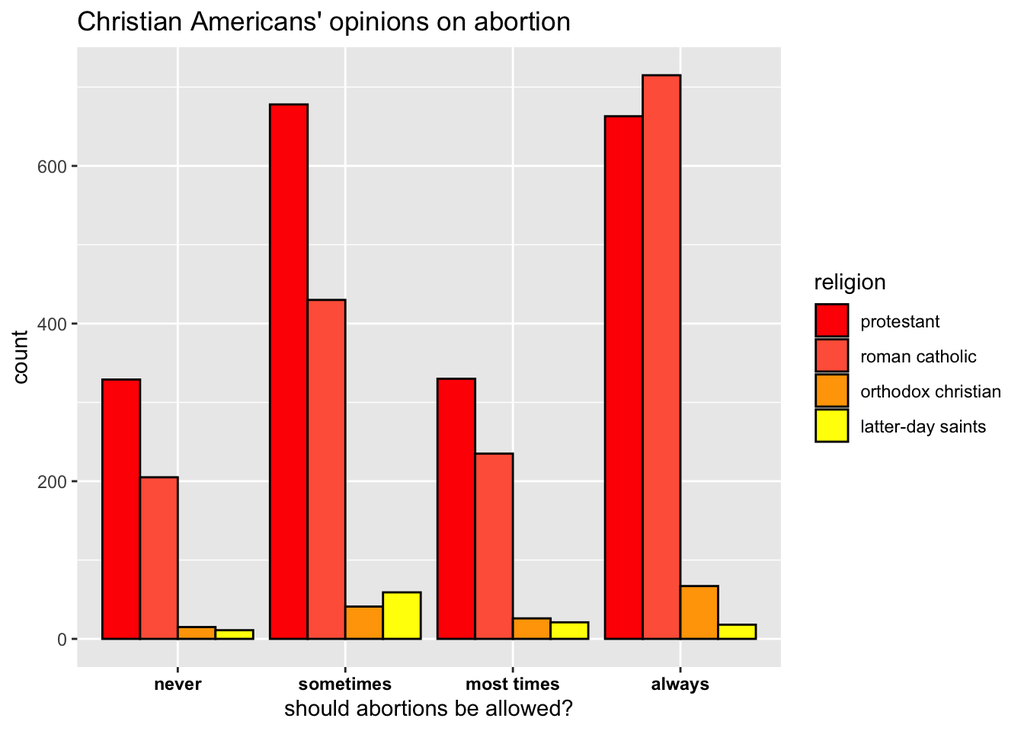

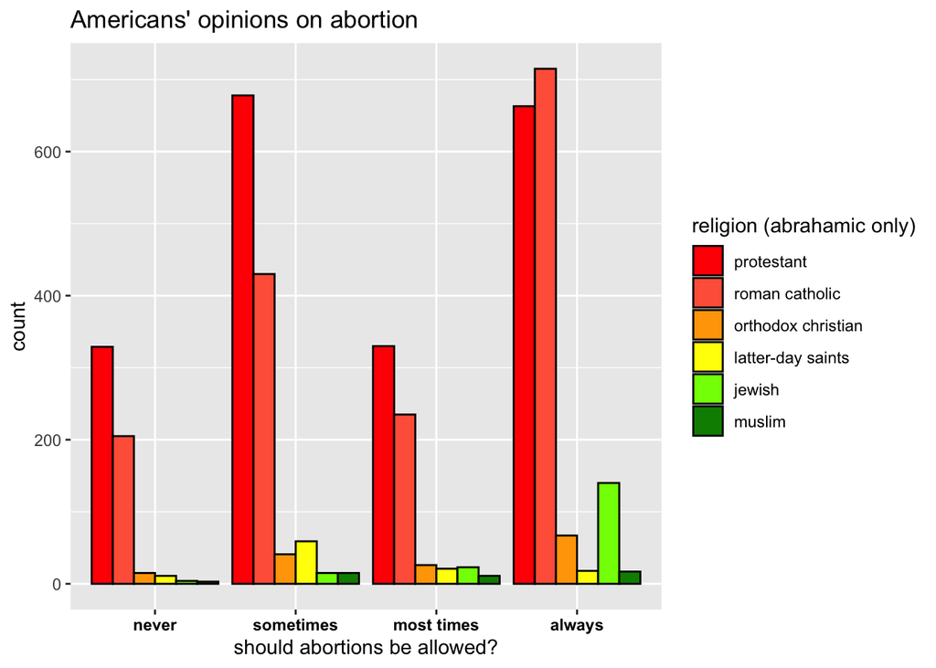

###### Figure 10

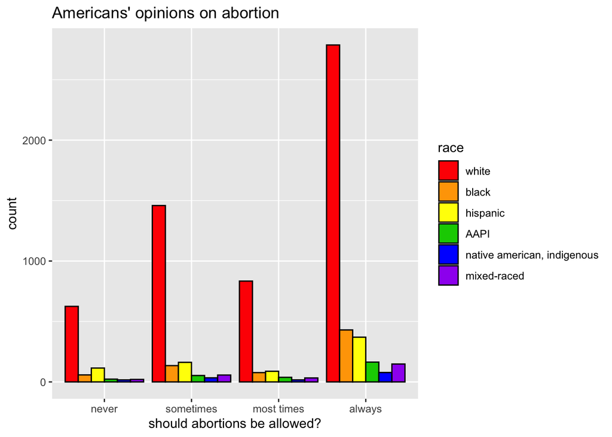

###### Figure 11

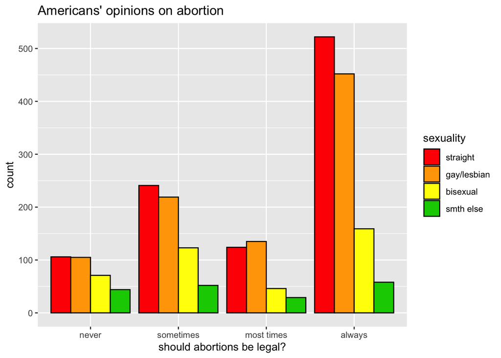

### Discussion

From the data, we can see that people who are against abortion are not always inherently against the death penalty, which is evidence that the disapproval of abortion has more motives than just the conservation of life. The data shows that most pro-lifers actually favour the death penalty. It can also be observed that a person’s political ideology (liberal or conservative) has a large impact on their opinions on abortion; the impact of other variables, such as sex and race, on abortion opinions are not as large. These findings allow us to better understand American politics and how different factors influence different opinions. After the overturning of Roe v. Wade, abortion rights have been put at high risk across the country. Despite most of the American population being supportive of abortion, the government was able to hinder abortion rights severely. This raises an important question: is the American population properly represented in the government? The purpose of this research is not to question or challenge the American government, but to shed light on relevant issues and become more aware of certain variables’ effects on politics. Before conducting my research, I thought age, religion, and sex would have a much more significant impact on abortion opinions than they actually did. Age and religion were slightly influential and sex was barely relevant. My null hypothesis and alternative hypothesis were both wrong, as there is just a little bit of correlation between one’s opinion on the death penalty and abortion. If I had more time I would investigate other variables, such as income or state of registration, and see if I could somehow get an accuracy of 70% or higher with one of my models.

### Code and Data Availability

All of my code can be found in the folder titled “WeisProject” in [this GitHub repository](https://github.com/the-codingschool/ANES-dataset-analysis). The raw data can be found as a csv file titled “anesplease.csv” in the same folder. This is the link to the [original dataset](https://electionstudies.org/data-center/2020-time-series-study/); these are the links to the [survey variable guide](https://electionstudies.org/wp-content/uploads/2021/07/anes_timeseries_2020_methodology_userguidecodebook_20210719.pdf) and [non-survey variable guide](https://electionstudies.org/wp-content/uploads/2022/02/anes_timeseries_2020_userguidecodebook_20220210.pdf))